# CQF Module 4 - Report

## Part C

**Model Building, Tuning and Evaluation**  
Predicting Positive Market Moves Using Support Vector Support Vector Machine (SVM)

#### C1.) Data setup for final modelling

```python
# Loading patched dataset
if PARQ.exists():
    df = pd.read_parquet(PARQ)
else:
    df = pd.read_csv(CSV, parse_dates=["Date"]).set_index("Date")

df = df[df.index >= SAMPLE_START].copy()

print(df.shape)

# use previously selected final features
final_features = final_features

TARGET = 'y'
X_final = df[final_features].copy()
y_final = df[TARGET].astype(int)

print("Final feature shape:", X_final.shape)
print("Positive class proportion:", y_final.mean().round(3))
```

```
(2804, 50)
Final feature shape: (2804, 11)
Positive class proportion: 0.326
```

#### C2.) Chronological train/test split

```python
TEST_PCT = 0.2  # 20% test
split_idx = int(len(X_final) * (1 - TEST_PCT))

X_train, X_test = X_final.iloc[:split_idx], X_final.iloc[split_idx:]
y_train, y_test = y_final.iloc[:split_idx], y_final.iloc[split_idx:]

print("Train:", X_train.shape, "Test:", X_test.shape)
print("Train range:", X_train.index.min(), "→", X_train.index.max())
print("Test  range:", X_test.index.min(),  "→", X_test.index.max())
```

```
Train: (2243, 11) Test: (561, 11)
Train range: 2015-01-01 00:00:00 → 2023-08-07 00:00:00
Test  range: 2023-08-08 00:00:00 → 2025-09-30 00:00:00
```

#### C3.) SVM pipeline (imputer + scaler + SVC)

```python
#### C3.) SVM pipeline (imputer + scaler + SVC)

svm_pipe = Pipeline(steps=[
    ("imputer", SimpleImputer(strategy="median")),
    ("scaler", StandardScaler()),
    ("clf", SVC(probability=True, class_weight="balanced", random_state=42))
])

svm_pipe.fit(X_train, y_train)
```

```
Pipeline(steps=[('imputer', SimpleImputer(strategy='median')),
                ('scaler', StandardScaler()),
                ('clf',
                 SVC(class_weight='balanced', probability=True,
                     random_state=42))])
```

#### C4.) Hyperparameter tuning with Time-Series CV and Grid Search method

```python
#### C4.) Hyperparameter tuning with Time-Series CV and Grid Search method
tscv = TimeSeriesSplit(n_splits=5)
param_grid = {
    "clf__kernel": ["rbf", "poly"],
    "clf__C": [0.5, 1, 2, 5, 10],
    "clf__gamma": ["scale", 0.1, 0.05, 0.01],
    "clf__degree": [2, 3]  # only used if kernel='poly'
}

scoring = {"roc_auc": "roc_auc", "f1": "f1", "accuracy": "accuracy"}

grid = GridSearchCV(
    estimator=svm_pipe,
    param_grid=param_grid,
    scoring=scoring,
    refit="roc_auc",     # optimize for ROC-AUC
    cv=tscv,
    verbose=2,
    n_jobs=-1
)

grid.fit(X_train, y_train)

print("Best params:", grid.best_params_)
print("Best cross-val ROC-AUC:", round(grid.best_score_, 4))
```

```
Fitting 5 folds for each of 80 candidates, totalling 400 fits
Best params: {'clf__C': 0.5, 'clf__degree': 2, 'clf__gamma': 0.01, 'clf__kernel': 'rbf'}
Best cross-val ROC-AUC: 0.605
```

#### C5.) Evaluate on held-out test set

```python
# --- Test set evaluation ---

best_model = grid.best_estimator_
y_pred = best_model.predict(X_test)
y_proba = best_model.predict_proba(X_test)[:, 1]

# --- Metrics ---
print("Test ROC-AUC:", round(roc_auc_score(y_test, y_proba), 4))
print("Accuracy:", round(accuracy_score(y_test, y_pred), 4))
print("Precision:", round(precision_score(y_test, y_pred), 4))
print("Recall:", round(recall_score(y_test, y_pred), 4))
print("F1:", round(f1_score(y_test, y_pred), 4))

print("\nClassification Report:\n", classification_report(y_test, y_pred, digits=3))
```

```
Test ROC-AUC: 0.6129
Accuracy: 0.5419
Precision: 0.3861
Recall: 0.6595
F1: 0.487

Classification Report:
               precision    recall  f1-score   support

           0      0.743     0.484     0.586       376
           1      0.386     0.659     0.487       185

    accuracy                          0.542       561
   macro avg      0.564     0.572     0.537       561
weighted avg      0.625     0.542     0.553       561
```

#### C6.) ROC Curve

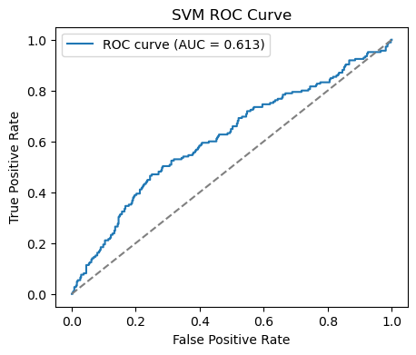

```python
fpr, tpr, _ = roc_curve(y_test, y_proba)
plt.figure(figsize=(5,4))
plt.plot(fpr, tpr, label=f"ROC curve (AUC = {roc_auc_score(y_test, y_proba):.3f})")
plt.plot([0,1],[0,1],"--",color="gray")
plt.xlabel("False Positive Rate")
plt.ylabel("True Positive Rate")
plt.title("SVM ROC Curve")
plt.legend()
plt.show()
```

#### C7.) Confusion Matrix

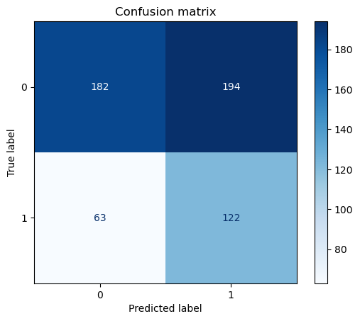

```python
# Display confussion matrix
disp = ConfusionMatrixDisplay.from_estimator(
        best_model,
        X_test,
        y_test,
        # display_labels=model.classes_,
        cmap=plt.cm.Blues
    )
plt.title('Confusion matrix')
plt.show()
```

## Trading Strategy

We will now define a trading strategy based on the predicted signals from our model. These signals will determine whether to enter a buy or sell position. The performance of this strategy will then be compared against a buy-and-hold strategy to evaluate its effectiveness. Finally, we will visualize and analyze the results to assess how well the machine learning algorithm performs in a real-world trading scenario.

```python
# Subsume into a new dataframe
df2 = X_final.copy()                              # df[-len(X_test)
df2['Signal'] = best_model.predict(X_final)        # tunedmodel.predict(X_test)
```

```python
X_final.columns
```

```
Index(['vix_level', 'snp500_ret_1', 'qqq_rsi_20', 'risk_aversion_proxy',
       'tlt_ret_5', 'qqq_vol_20', 'qqq_vol_z', 'qqq_logret_1', 'qqq_lb_5',
       'qqq_volume', 'qqq_atr_20'],
      dtype='object')
```

```python
# Daily Returns - Benchmark return
df2['Returns'] = dailyReturn(df[f'{MAIN_TICKER}_close']).shift(-1)

# Strategy Returns - Logistic
df2['Strategy'] =  df2['Returns'] * df2['Signal'].shift(1).fillna(0)

# Localize index for pyfolio
df2.index = df2.index.tz_localize('utc')
# Check the output
# df2.shape
# df2.head(5)
```

| Start date End date Total months | 2015-01-01 2025-09-30 133 Backtest | 2015-01-01 2025-09-30 133 |
| --- | --- | --- |
| Annual return | 8.689% |  |
| Cumulative returns | 152.709% |  |
| Annual volatility | 19.12% |  |
| Sharpe ratio | 0.53 |  |
| Calmar ratio | 0.23 |  |
| Stability | 0.77 |  |
| Max drawdown | -37.214% |  |
| Omega ratio | 1.15 |  |
| Sortino ratio | 0.74 |  |
| Skew | NaN |  |
| Kurtosis | NaN |  |
| Tail ratio | 0.99 |  |
| Daily value at risk | -2.369% |  |

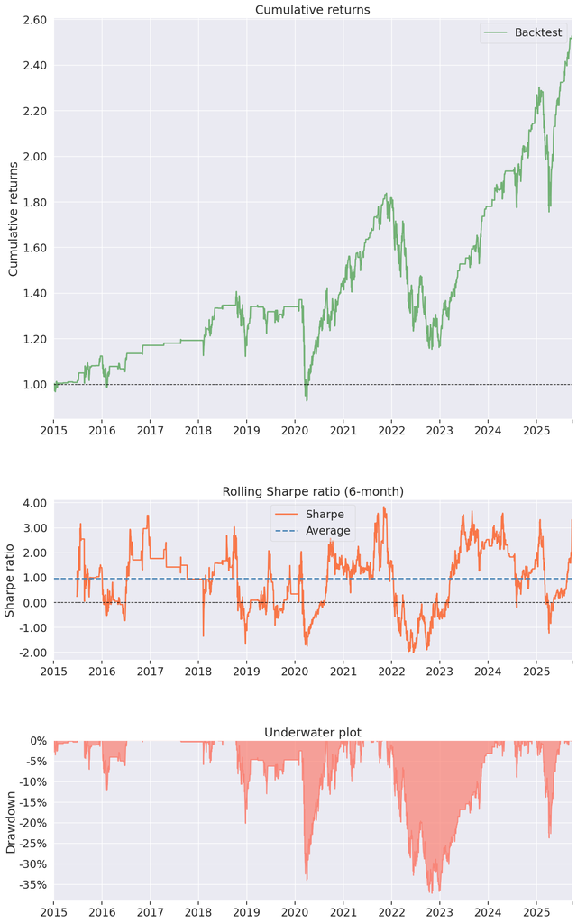

```python
# Create Tear sheet using pyfolio for outsample - for X_test
pf.create_simple_tear_sheet(df2['Strategy'])
```

| Start date End date In-sample months Out-of-sample months | 2015-01-01 2025-09-30 106 26 In-sample | 2015-01-01 2025-09-30 106 26 Out-of-sample | 2015-01-01 2025-09-30 106 26 All | 2015-01-01 2025-09-30 106 26 |
| --- | --- | --- | --- | --- |
| Annual return | 5.074% | 24.426% | 8.689% |  |
| Cumulative returns | 55.356% | 62.665% | 152.709% |  |
| Annual volatility | 19.478% | 17.606% | 19.12% |  |
| Sharpe ratio | 0.35 | 1.33 | 0.53 |  |
| Calmar ratio | 0.14 | 1.03 | 0.23 |  |
| Stability | 0.59 | 0.84 | 0.77 |  |
| Max drawdown | -37.214% | -23.75% | -37.214% |  |
| Omega ratio | 1.09 | 1.40 | 1.15 |  |
| Sortino ratio | 0.48 | 2.01 | 0.74 |  |
| Skew | -0.73 | NaN | NaN |  |
| Kurtosis | 12.58 | NaN | NaN |  |
| Tail ratio | 0.96 | 0.93 | 0.99 |  |
| Daily value at risk | -2.427% | -2.125% | -2.369% |  |
| Alpha | -0.05 | 0.06 | -0.03 |  |
| Beta | 0.78 | 0.78 | 0.78 |  |

| Worst drawdown periods | Net drawdown in % | Peak date | Valley date | Recovery date | Duration |
| --- | --- | --- | --- | --- | --- |
| 0 | 37.21 | 2021-11-24 | 2022-11-02 | 2024-02-21 | 586 |
| 1 | 34.07 | 2018-10-16 | 2020-03-31 | 2020-08-25 | 486 |
| 2 | 23.75 | 2025-01-22 | 2025-04-07 | 2025-06-27 | 113 |
| 3 | 13.15 | 2020-09-01 | 2020-09-22 | 2020-12-14 | 75 |
| 4 | 12.27 | 2015-12-22 | 2016-02-08 | 2016-07-07 | 143 |

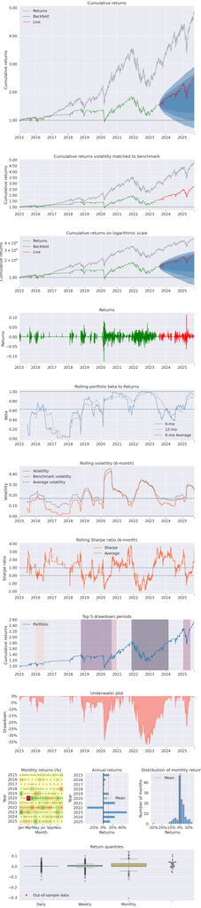

```python
# Live start date 2016-04-07
pf.create_returns_tear_sheet(df2['Strategy'], live_start_date=X_test.index.min(), benchmark_rets=df2['Returns'])
```